# Workshop module 1: Electric field

# True or false (and why)

# Questions

1. Suppose you have a positive charge $q$ that you want to distribute in two different bodies. How do you have to distribute the electrical charge between them so that electrical repulsion is maximum?
   - Electric force is proportional to the product of charges $F\propto (q-x)x\implies dF/dx\propto(q-2x)$. Then $dF/dx=0\implies x=q/2$. Equal distribution between bodies.
2. Choose the figure that best represents Coulomb force as a function of distance.

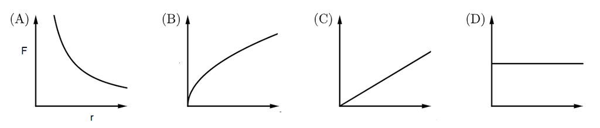

# Problems

## Problem 1

At the end points of a straight tube of length $L$ there are two charges $Q_1$ and $Q_2=2Q_1$, respectively. A small metallic sphere of charge $Q$ lies within, which can freely move along the tube.

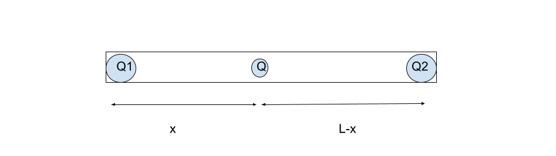

Find:

- a) The equilibrium position $x$ of the sphere.
- b) is the equilibrium stable?
- c) it would be stable without the tube?
- d) it would be stable if the charge $Q$ were negative?

*Answer*:

- a) $\frac{kQ_1Q}{x^2}=\frac{kQ_2Q}{(l-x)^2}\implies \frac{1}{x^2}=\frac{2}{(l-x)^2}\implies x\simeq 0.41l$
- b) the equilibrium is stable
- c) it would not be stable
- d) it would not be stable

## Problem 2

Positive charge Q is uniformly distributed along the positive $y$-axis between as indicated in the figure. Another point charge $q$ is located on the $x$-axis at $x=a$. Calculate the electric field experienced by $q$.

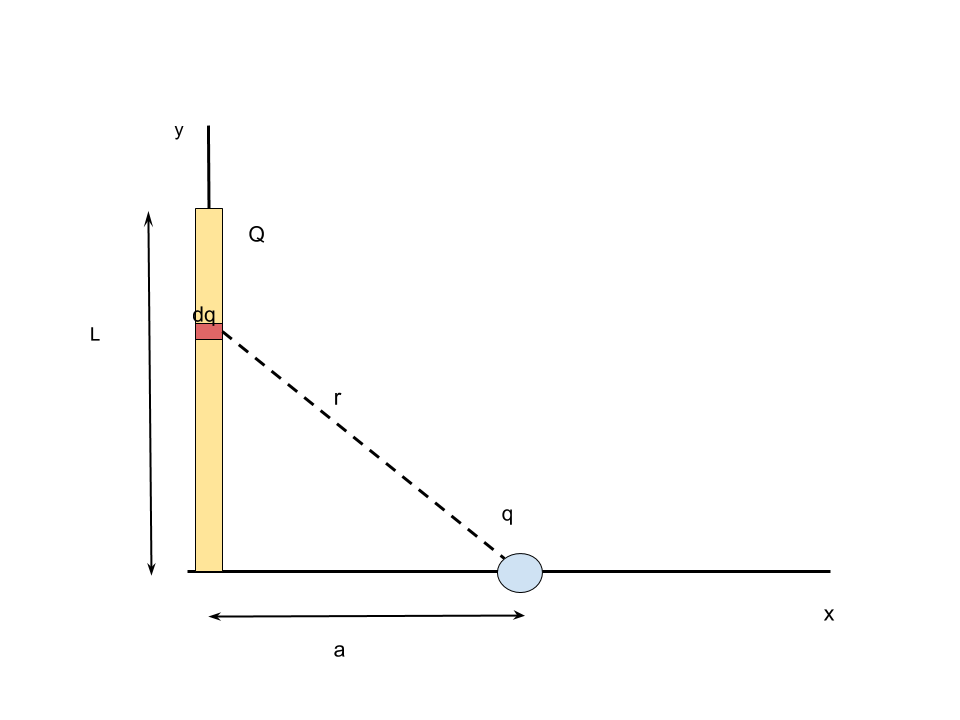

*Answer* One way: calculate the electric potential and then take the gradient. Here we rely on a direct integration of the electric field. Two approaches to get the same answer seen in the workshop, a "geometric approach" and a "systematic approach" (I personally prefer the latter one).

The geometric approach: The **module** of the electric field at $x$ created by an infinitesimal charge $dq$ located at $y$ is

$$ d E=\frac{1}{4 \pi \epsilon_{0}}\frac{dq}{x^2+y^2}$$

What is $dq$? As we have a linear charge distribution, then by definition $dq=\lambda dL$. And what is dL in this case? dL=dy. Additionally, it's straightforward to notice that $\lambda=Q/L$ in this case. Thus,

$$ dE=\frac{Q}{4 \pi \epsilon_{0}L}\frac{dy}{x^2+y^2}$$

Now, in looking at the figure, the components of the vector (the electric field is a vector, not its module!) must be

$$ \begin{array}{l} d E_{x}=d E \cos \theta=\frac{Q x}{4 \pi \epsilon_{0} L}\left(\frac{d y}{\left(x^{2}+y^{2}\right)^{3 / 2}}\right) \\ d E_{y}=-d E \sin \theta=-\frac{Q}{4 \pi \epsilon_{0} L}\left(\frac{y d y}{\left(x^{2}+y^{2}\right)^{3 / 2}}\right) \\ \end{array} $$

where

$$ \begin{array}{l} \sin \theta=\frac{y}{\sqrt{x^{2}+y^{2}}} \\ \cos \theta=\frac{x}{\sqrt{x^{2}+y^{2}}} \end{array} $$

Integrating we obtain the electric field ($\vec E=E_x\hat i+E_y \hat j$)

$$ \begin{array}{l} E_{x}=\int d E_{x}=\frac{Q x}{4 \pi \epsilon_{0} L} \int_{0}^{L} \frac{d y}{\left(x^{2}+y^{2}\right)^{3 / 2}}=\frac{Q x}{4 \pi \epsilon_{0} L}\left[\frac{1}{x^{2}} \frac{y}{\sqrt{x^{2}+y^{2}}}\right]_{0}^{L}=\frac{Q}{4 \pi \epsilon_{0} x} \frac{1}{\sqrt{x^{2}+L^{2}}} \\ E_{y}=\int d E y=-\frac{Q}{4 \pi \epsilon_{0} L} \int_{0}^{L} \frac{y d y}{\left(x^{2}+y^{2}\right)^{3 / 2}}=-\frac{Q}{4 \pi \epsilon_{0} L}\left[-\frac{1}{\sqrt{x^{2}+y^{2}}}\right]_{0}^{L}=-\frac{Q}{4 \pi \epsilon_{0} L}\left(\frac{1}{x}-\frac{1}{\sqrt{x^{2}+L^{2}}}\right) \end{array} $$

The systematic approach:

The general expression for the electric field created by $dq$ is

$$ d\vec E=\frac{1}{4 \pi \epsilon_{0}}\frac{dq(\vec r-\vec r')}{|\vec r-\vec r'|^3}$$

Let's identify terms

$$\begin{array} \vec r=x\hat i \\ \vec r'=y\hat j \\ \vec r-\vec r'=x\hat i-y\hat j \\ |\vec r-\vec r'|^3=(x^2+y^2)^{3/2} \\ dq=\lambda dL=Qdy/L \\ \end{array}$$

Hence

$$ d\vec E=\frac{Q}{4 \pi \epsilon_{0}L}\frac{dy(x\hat i-y\hat j)}{(x^2+y^2)^{3/2}}$$

Integrating the previous expression we obtain the same results as before.

## Problem 3

Calculate the electric field at any point created by an infinitely large cylinder of radius $R$ with a charge density

$$\begin{array}{ll}\rho(r)=\rho_{0}(1-r / R) & \text { for } r \leq R \\ \rho(r)=0 & \text { for } r \geq R\end{array}$$

where $r$ is the distance from the axis of the cylinder.

*Answer*:

By choosing a cylinder of radius $r$ as a gaussian surface (over which the electric field is constant), applying the Gauss law we obtain

$$\int \vec E\cdot dS=E(2\pi rL)=Q_{enc}/\epsilon_0$$

$r>R$: $$Q_{enc}=Q_{Total}=\int_0^R\rho(r)dV=\rho_0\int_0^R(1-r/R)(2\pi rLdr)=2\pi\rho_0L(\frac{R^2}{2}-\frac{R^3}{3R})=\pi/3\rho_0LR^2$$ $$E(2\pi rL)=\pi\rho_0 LR^2/(3\epsilon_0)\implies \vec E=\frac{\rho_0R^2}{6\epsilon_0r}\hat r$$ $r<R$: $$Q_{enc}=\int_0^r\rho(r')dV=\rho_0\int_0^r(1-r'/R)(2\pi r'Ldr')=2\pi\rho_0L(\frac{r^2}{2}-\frac{r^3}{3R})$$ $$E(2\pi rL)=\frac{2\pi\rho_0L}{\epsilon_0}(\frac{r^2}{2}-\frac{r^3}{3R})\implies \vec E=\frac{\rho_0}{\epsilon_0}(\frac{r}{2}-\frac{r^2}{3R})\hat r$$

## Problem 4

Three point charges are located on the $x$-axis. $Q_1=2nC$ at $x=0$, $Q_2=-3nC$ at $x=20cm$ and $Q_3=5nC$ at $x=10cm$. Assume that the energy is zero when charges are infinitely separated.

- a) What is the potential energy of this configuration?
- b) Having fixed $Q_1$ and $Q_2$, where should I place $Q_3$ so that the total energy is zero?

*Answer*:

- a) $U=_{ij}=k\frac{Q_iQ_i}{r_{ij}}$ so $U_{12}=-2.7\times 10^{-7}J$,$U_{13}=9.0\times 10^{-7}J$,$U_{23}=-13.5\times 10^{-7}J$. $U=-7.2\times 10^{-7}J$
- b) let $x=r_{13}\implies r_{23}=0.2(m)-x$. Then $U(x)=k\frac{Q_1Q_2}{0.2}+k\frac{Q_2Q_3}{(0.2-x)}+k\frac{Q_1Q_3}{x}\implies 30x^2-31x+2=0\implies x_1=6.9cm,x_2=96.4cm$

## Problem 5

The electric potential in a certain region of space is given by $V(x,y)=ax^2+bxy+cy$, with $a=3V/m^2,b=-2V/m^2,c=5V/m^2$. Find

- a) The electric field $\vec E(x,y)$.
- b) The work done by the electric field when moving a proton from $x=0m$ to $x=1m$.

*Answer*:

- a) $\vec E=-\nabla V=-(2ax+by)\hat i-(bx+c)\hat j$
- b) Using the electric potential $W=-\Delta U=-e(V(x=1m,y=0m)-V(x=0m,y=0m))=-3(eV)$. Using the definition of work, $W=\int_{x=0m}^{x=1m}e\vec E(x,y=0)\cdot d\vec l=-2ae[x^2/2]_{x=0m}^{x=1m}=-3(eV)$

## Problem 6

A parallel-plate capacitor with area $A=500cm^2$ and separation $d=5mm$ has a voltage of $V_0=2000V$. Introducing a dielectric between its plates reduces the voltage to $V=1000V$. Find

- a) The capacity after introducing the dielectric.
- b) The relative permittivity.
- c) The induced charge on each surface of the dielectric.

*Answer*:

- a) Before we introduce the dielectric, we can write $C_0=Q_0/V_0$ and $C_0=\epsilon_0A/d$. From these two equations we can obtain the charge $Q_0=(\epsilon_0A/d)V_0=1.7\times 10^{-7}C$.

Once the dielectric is introduced, the charge on the metal plates remains the same ($Q_0$), although the difference of potential does change (bear in mind that the capacitor is isolated,not connected to any battery). Therefore $C=Q_0/V=1.7\times 10^{-7}C/1000V=1.7\times 10^{-4}\mu F$

- b) Applying the definition of relative permittivity, $\epsilon_r=C/C_0=V_0/V=2$.
- c) The dielectric gets polarized after being introduced between the plates of the capacitor. This means that a new superficial charge distribution appears on the surface of the dielectric, $\sigma_i$, with opposite sign with respect to the charge of the metal plate. The module of the electric field between the plates will be now

$$E=\frac{\sigma-\sigma_i}{\epsilon_0},$$

where $\sigma=Q_0/A$ and $\sigma_i=Q_i/A$.

## Problem 7

Suppose we connect a couple of capacitors in series, with capacitance of $150nF$ and $120nF$ respectively. Knowing that the potential difference across them is $36V$. Find:

- a) the total charge stored in the network.
- b) the charge on each capacitor.
- c) the total energy stored in the network.
- d) the energy stored in each capacitor.
- e) the potential differences across each capacitor.

*Answer*

The capacitors are in series, so the overall capacitance of the network is

$$ C_{\mathrm{eq}}=\frac{C_{1} C_{2}}{C_{1}+C_{2}}=\frac{(150 \mathrm{nF})(120 \mathrm{nF})}{150 \mathrm{nF}+120 \mathrm{nF}}=66.7 \mathrm{nF} $$

a) The total charge is then $$ Q=C V=(66.7 \mathrm{nF})(36 \mathrm{~V})=2.4 \times 10^{-6} \mathrm{C}=2.4 \mu \mathrm{C} $$

b) As they are in series, each capacitor will store the same amount of electrical charge on its plates regardless of its capacitance. This is because the charge stored by a plate of any one capacitor must have come from the plate of its adjacent capacitor. $Q_1=Q_2=2.4 \mu \mathrm{C}$

c) $$ U=\frac{1}{2} C_{\mathrm{eq}} V^{2}=\frac{1}{2}\left(66.7 \times 10^{-9} \mathrm{~F}\right)(36 \mathrm{~V})^{2}=43.2 \mu \mathrm{J} $$

d) We know $C$ and $Q$ for each capacitor, and we can write $U$ in term of these

$$ U=\frac{1}{2} C V^{2}=\frac{1}{2} C(Q / C)^{2}=Q^{2} / 2 C $$$$ 150 \mathrm{nF}: U=\frac{\left(2.4 \times 10^{-6} \mathrm{C}\right)^{2}}{2\left(150 \times 10^{-9} \mathrm{~F}\right)}=19.2 \mu \mathrm{J} ; 120 \mathrm{nF}: U=\frac{\left(2.4 \times 10^{-6} \mathrm{C}\right)^{2}}{2\left(120 \times 10^{-9} \mathrm{~F}\right)}=24.0 \mu \mathrm{J} $$

The sum of these two energies is obviously the total energy from c)

e) $$ 150 \mathrm{nF}: V=\frac{Q}{C}=\frac{2.4 \times 10^{-6} \mathrm{C}}{150 \times 10^{-9} \mathrm{~F}}=16 \mathrm{~V} ; 120 \mathrm{nF}: V=\frac{Q}{C}=\frac{2.4 \times 10^{-6} \mathrm{C}}{120 \times 10^{-9} \mathrm{~F}}=20 \mathrm{~V} $$

Notice that these values add up to $36V$, the voltage across the capacitors in series.

## Problem 8

Electronic flash units for cameras contain a capacitor for storing the energy used to produce the flash. In one such unit, the flash lasts for $(1/675)$ seconds with an average light power output of $2.7\times 10^5 W$.

- a) If the conversion of electrical energy to light is 95% efficient (the rest of the energy goes to thermal energy), how much energy must be stored in the capacitor for one flash?
- b) If the capacitor has a potential difference between its plates of 125V, what is the capacitance?

*Answer*

a) The power output is $2.70 \times 10^5 W$ and 95% of the original energy is converted. Thus,

$$ E=P t=\left(2.70 \times 10^{5} \mathrm{~W}\right)\left(1.48 \times 10^{-3} \mathrm{~s}\right)=400 \mathrm{~J} . \quad \implies U=\frac{400 \mathrm{~J}}{0.95}=421 \mathrm{~J} $$

b) $$ U=\frac{1}{2} C V^{2} \implies C=\frac{2 U}{V^{2}}=\frac{2(421 \mathrm{~J})}{(125 \mathrm{~V})^{2}}=0.054 \mathrm{~F} $$

## Problem 9

A parallel-plate capacitor is made from two plates $12 cm$ on each side and $4.50 mm$ apart. Half of the space between these plates contains only air, but the other half is filled with Plexiglas of relative permittivity 3.40 as shown below. An 18.0-V battery is connected across the plates.

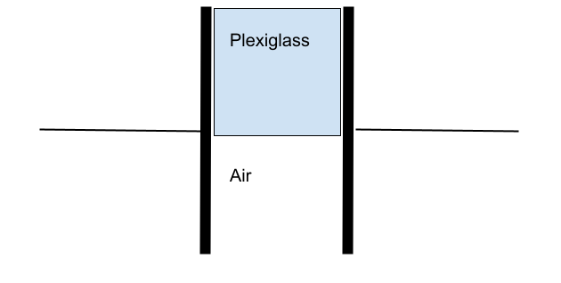

- a) What is the capacitance of this combination? Assume this capacitor as equivalent to two capacitors in parallel
- b) How much energy is stored in the capacitor?
- c) If we remove the Plexiglas but change nothing else, how much energy will be stored in the capacitor?

*Answer*

The capacitor is equivalent to two capacitors in parallel, and each of these two capacitors have plates that are $12.0 cm$ by $6.0 cm$.

a) $$C_{2}=\epsilon_{0} \frac{A}{d}=\frac{\left(8.854 \times 10^{-12} \mathrm{F} \mathrm{m}\right)(0.120 \mathrm{m})(0.060 \mathrm{m})}{4.50 \times 10^{-3} \mathrm{m}}=1.42 \times 10^{-11} \mathrm{F} . \\ C_{1}=\epsilon_r C_{2}=(3.40)\left(1.42 \times 10^{-11} \mathrm{F}\right)=4.83 \times 10^{-11} \mathrm{F} . \\ C=C_{1}+C_{2}=6.25 \times 10^{-11} \mathrm{F}=62.5 \mathrm{pF} $$

b) $$ U=\frac{1}{2} C V^{2}=\frac{1}{2}\left(6.25 \times 10^{-11} \mathrm{F}\right)(18.0 \mathrm{V})^{2}=1.01 \times 10^{-8} \mathrm{J} $$

c) After removing the dielectric, now we have that $C_1=C_2$. so

$$ C=2\left(1.42 \times 10^{-11} \mathrm{F}\right)=2.84 \times 10^{-11} \mathrm{F} $$$$ U=\frac{1}{2} C V^{2}=\frac{1}{2}\left(2.84 \times 10^{-11} \mathrm{~F}\right)(18.0 \mathrm{~V})^{2}=4.60 \times 10^{-9} \mathrm{~J} $$

## Problem 10

Calculate how much the capacitance varies when we introduce a layer of methacrylate $d/2$ thick, as illustrated below. In other words, calculate the ratio $\frac{C_{\text {final}}}{C_{\text {initial}}}$. (Hint: for this calculation you will probably want to determine the voltage $V$ between the plates. Assume that the electric field between the plates is like the one created by an infinite parallel-plate capacitor, so you can use the expression for the electric field given in the class notes for two oppositely charged infinite sheets, the only difference is that you have to take into account that there are two regions with different permittivity)

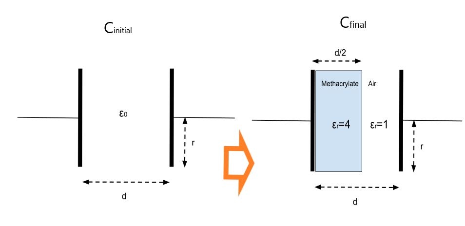

*Answer*

We can describe this configuration in terms of two parallel-plate capacitors in series. Then $\frac{1}{C_f}=\frac{1}{C_1}+\frac{1}{C_2}$, where $C_1=\epsilon_r\epsilon_0\frac{A}{d/2}$ and $C_2=\epsilon_0\frac{A}{d/2}$. On the other hand, $C_i=\epsilon_0\frac{A}{d}$. It is then trivial to see that,

$\frac{C_f}{C_0}=\frac{8}{5}$